# How to Codebook

Felix Schönbrodt

felix.schoenbrodt@psy.lmu.de

Ludwig-Maximilians-Universität München

David Rieger

david.rieger@campus.lmu.de

Ludwig-Maximilians-Universität München

2026-04-17

# How to create a codebook aka. data dictionary

## How to Codebook

See the [D-Psy-FAIR](https://psycharchives.org/en/item/fe055282-d722-4468-8a8f-01e0cc3c0607) standard (developed by Blask et al from the Leibniz-Institute Psychology)

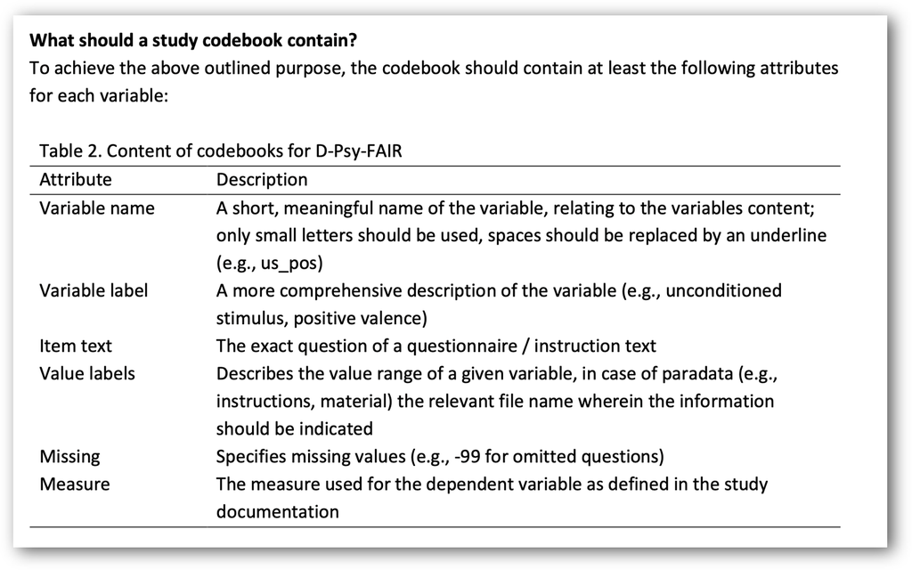

Save in a human-readable (e.g., .csv) and in a machine-readable (e.g., .json) format!

## Codebook: Which file format?

**Excel file:**  
Human-readable: ✅ ✅  
Machine-readabe: ~  
Accessible: ~

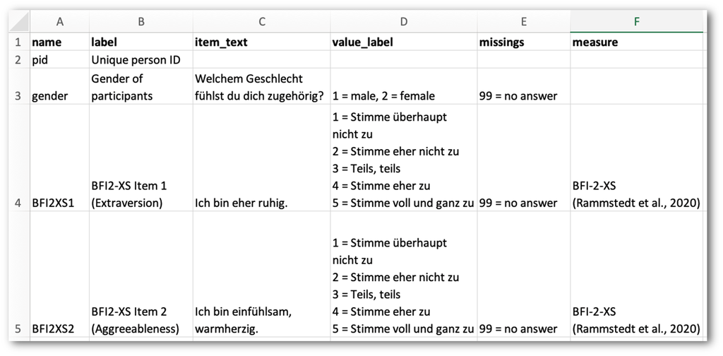

(Note re: “Accessible”: Proprietary file format; but as it is a widely used format, there are multiple open source apps which can open it). A better alternative is the open `.ods` spreadsheet format (e.g. from LibreOffice)

## Codebook: Which file format?

**csv file:**  
Human-readable: ~ (raw) ✅ (after import)  
Machine-readable: ✅  
Accessible: ✅

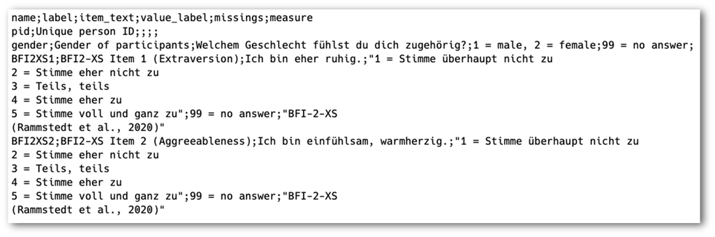

## Codebook: Which file format?

**json file:**  
Human-readable: ~ (raw)  
Machine-readable: ✅ ✅  
Accessible: ✅

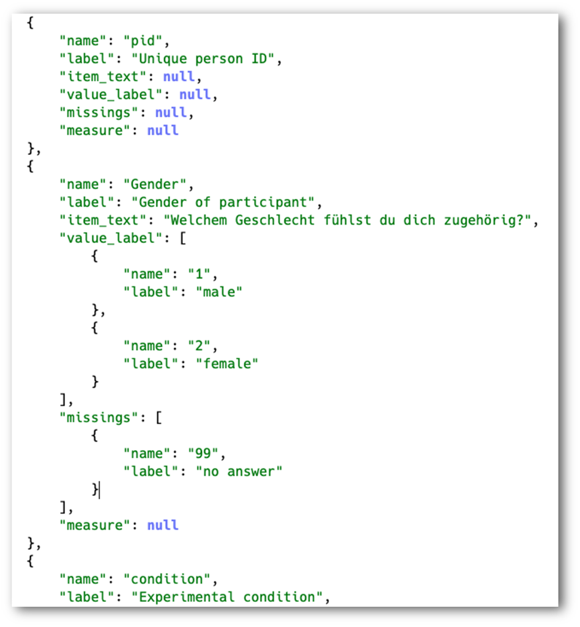

## Excursus: json file format

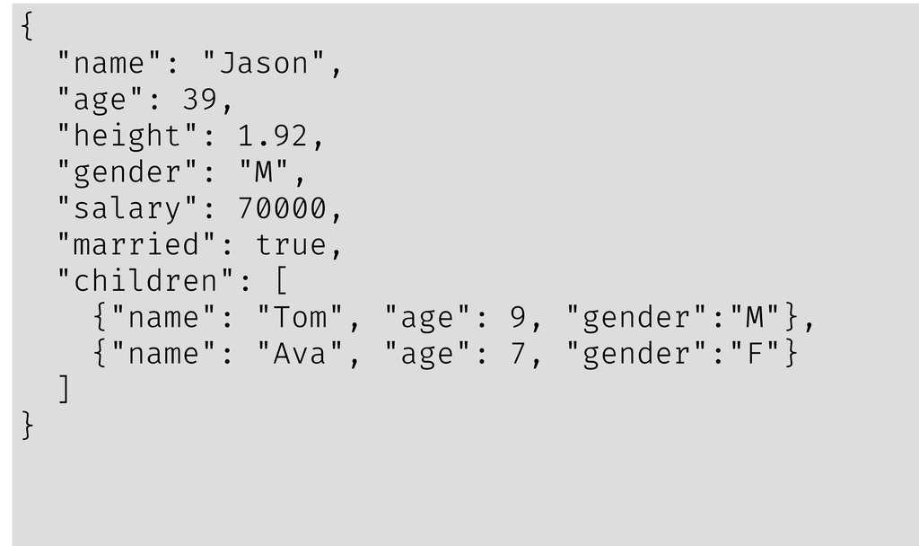

## Excursus: json file format

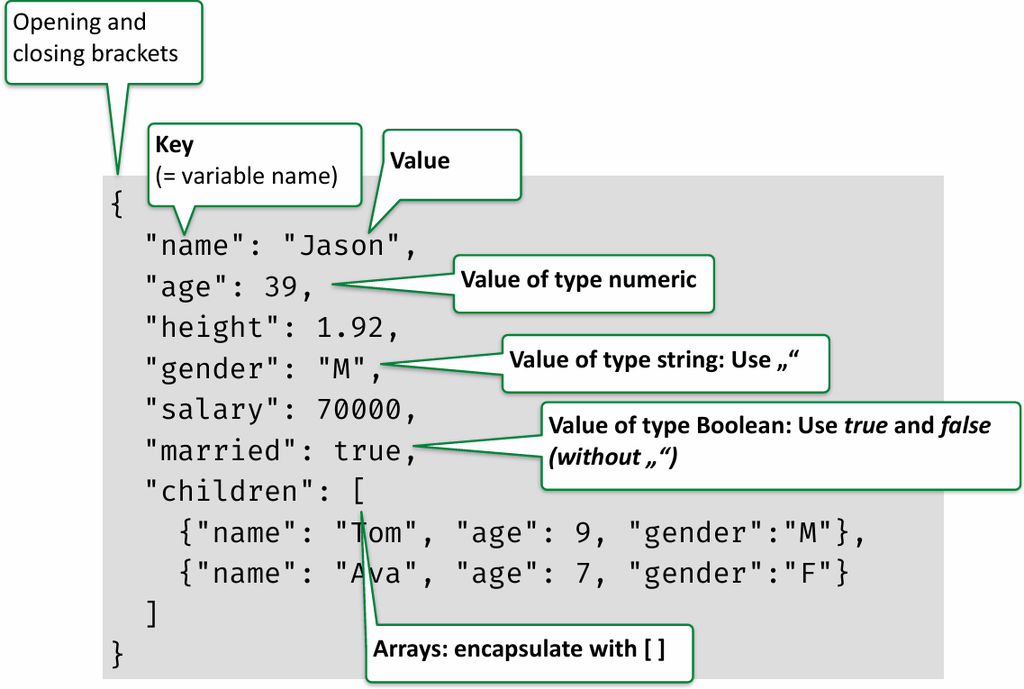

## How to Codebook: Manual

- Step 1: Create your codebook as an Excel or LibreOffice spreadsheet file
- Step 2: Export it as a `.csv` file
- Step 3: Import into R and convert it to a `.json` file

```r
library(jsonlite)
df <- read.csv("codebook.csv")
json <- toJSON(df, pretty = TRUE)
write_json(json,"codebook.json")
```

- Step 4: Save both codebook files in the `/doc` subfolder of your project
- Step 5: Upload both the `.csv` and the `.json`-file to the repository

## How to Codebook: DataWiz2

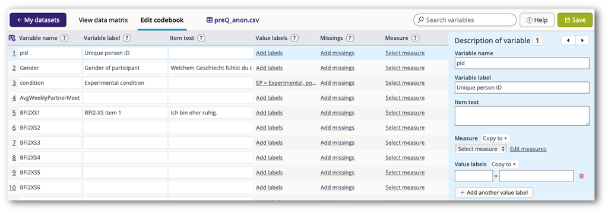

https://datawiz2.beta.zpid.org

## How to Codebook

- Resources:
- Video (51 min.): [“PTOS 9: Einführung in das Forschungsdatenmanagement mit D-Psy_FAIR“](https://zpid.cloud.panopto.eu/Panopto/Pages/Viewer.aspx?id=a8a6b29f-959e-44b2-b829-af5500be5bc7)  
  – siehe v.a.: „Schritt 2: Ein Codebuch erstellen“ ab 29:27

# End

## Contact

- [@nicebread@scicomm.xyz](https://scicomm.xyz/@nicebread)
- ed.uml.ysp@tdorbneohcs.xilef
- https://www.nicebread.de
- https://github.com/nicebread